# CDC Daily by State

davegoblue

8/3/2021

## Background

This file is designed to use CDC data to assess coronavirus disease burden by state, including creating and analyzing state-level clusters.

Through March 7, 2021, [The COVID Tracking Project](https://covidtracking.com/) collected and integrated data on tests, cases, hospitalizations, deaths, and the like by state and date. The latest code for using this data is available in Coronavirus_Statistics_CTP_v004.Rmd.

The COVID Tracking Project suggest that [US federal data sources](https://covidtracking.com/analysis-updates/federal-covid-data-101-how-to-find-data) are now sufficiently robust to be used for analyses that previously relied on COVID Tracking Project. This code is an attempt to update modules in Coronavirus_Statistics_CTP_v004.Rmd to leverage US federal data.

The code in this module builds on code available in _v002 to include vaccines data:

- Generic_Added_Utility_Functions_202105_v001.R - generic functions that can be used in other areas
- Coronavirus_CDC_Daily_Functions_v001.R - functions specific to coronavirus daily data

Broadly, the CDC data analyzed by this module includes:

- CDC case and death data by state and date are available for download on the [CDC website](https://data.cdc.gov/api/views/9mfq-cb36/rows.csv?accessType=DOWNLOAD)
- CDC hospital data are available for download on the [healthdata.gov website](https://beta.healthdata.gov/api/views/g62h-syeh/rows.csv?accessType=DOWNLOAD)
- CDC vaccines data are also available for download on the [CDC website](https://data.cdc.gov/api/views/unsk-b7fc/rows.csv?accessType=DOWNLOAD):

## Functions and Mapping Files

The tidyverse package is loaded and functions are sourced:

```r
# The tidyverse functions are routinely used without package::function format
library(tidyverse)
# Functions are available in source file
source("./Generic_Added_Utility_Functions_202105_v001.R")
source("./Coronavirus_CDC_Daily_Functions_v001.R")
```

A series of mapping files are also available to allow for parameterized processing. Mappings include:

- urlMapper - mapping file for urlType and url location to download data
- renMapper - mapping file for renaming of variables in the raw data file
- selfListMapper - mapping file for transformations by variable type
- fullListMapper - mapping file for transformations across variable types
- lstComboMapper - mapping file for elements to be combined by data type (most common is to combine NYC and NYS data to NY if the file provides them separately)
- uqMapper - mapping file for fields that should combine to be unique keys for processed files
- lstFilterMapper - mapping file for filtering to subset (most common is to keep 50 states and DC)
- vecSelectMapper - mapping file for variables to keep
- checkControlGroupMapper - mapping file for group_by() of control total checks
- checkControlAggMapper - mapping file for numeric variables for control total checks
- checkSimilarityMapper - mapping file for similarity checks to perform
- plotSimilarityMaooer - mapping file for fields where differences in universe should be plotted
- keyAggMapper - mapping file for the aggregate-level control total checks to perform
- perCapMapper - named vector that drives conversion from original field name to per capita field name

These default parameters are maintained in a separate .R file and can be sourced:

```r
source("./Coronavirus_CDC_Daily_Default_Mappings_v002.R")
```

## Example for Comparison to Previous

The function is tested on existing, previously downloaded data:

```
##
## No file has been downloaded, will use existing file: ./RInputFiles/Coronavirus/CDC_dc_downloaded_210801.csv
```

```
##
## *** File has been checked for uniqueness by: state date
```

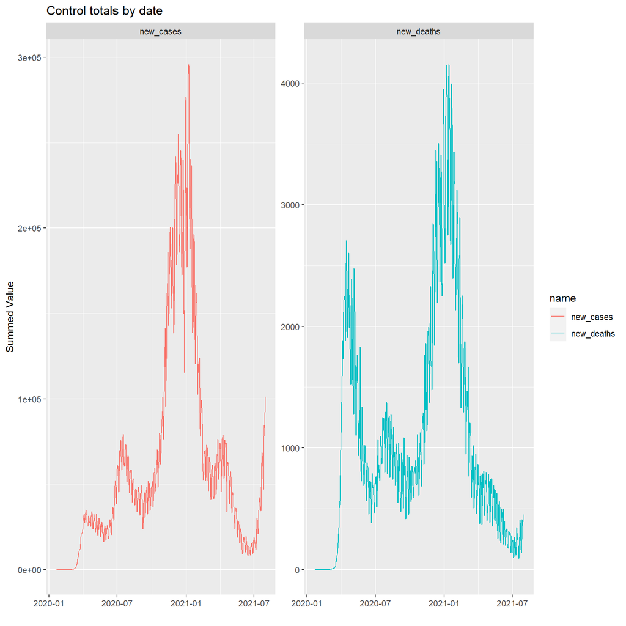

```
##
##
## Checking for similarity of: column names
## In reference but not in current:
## In current but not in reference:
##
## Checking for similarity of: date
## In reference but not in current: 0
## In current but not in reference: 25
##
## Checking for similarity of: state
## In reference but not in current:
## In current but not in reference:
```

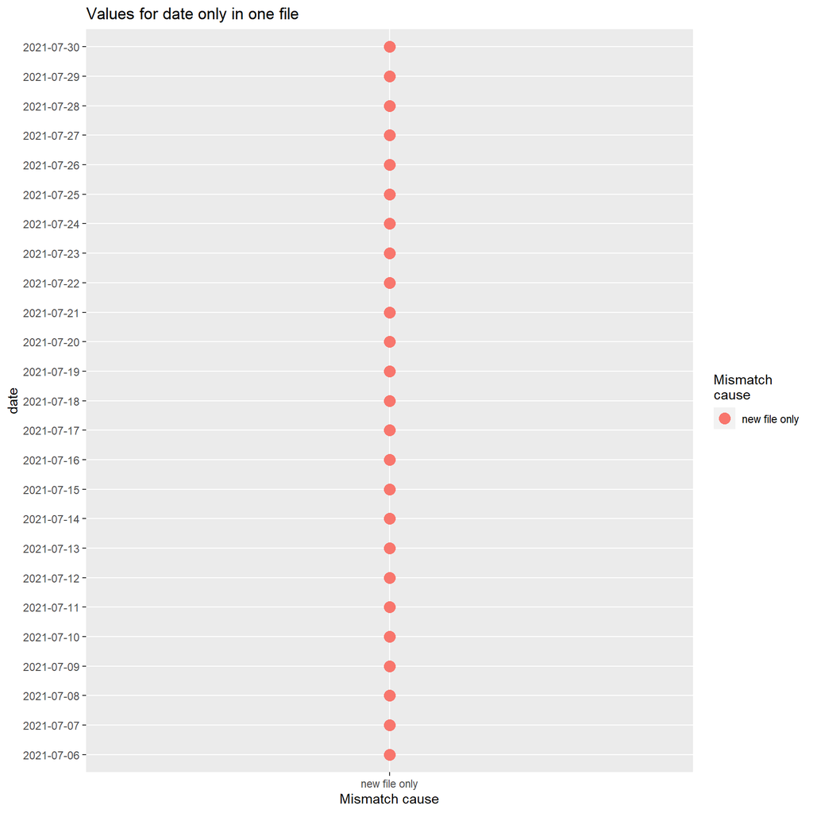

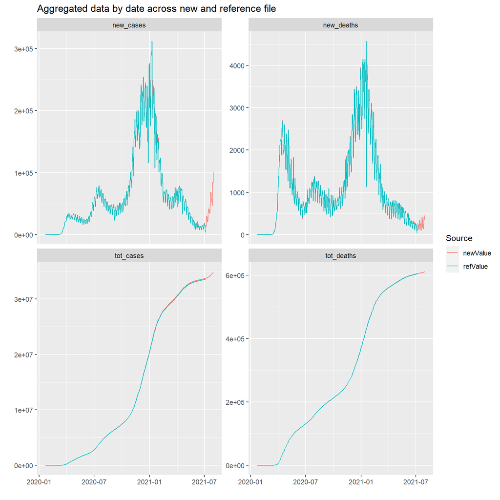

```
##
##
## ***Differences of at least 5 and at least 5%
##
##           date       name newValue refValue absDelta   pctDelta
## 1   2020-02-02 tot_deaths      143      152        9 0.06101695
## 2   2020-02-03 tot_deaths      143      152        9 0.06101695
## 3   2020-02-04 tot_deaths      143      152        9 0.06101695
## 4   2020-02-05 tot_deaths      143      152        9 0.06101695
## 5   2020-02-06 tot_deaths      143      152        9 0.06101695
## 6   2020-02-07 tot_deaths      143      152        9 0.06101695
## 7   2020-02-08 tot_deaths      144      153        9 0.06060606
## 8   2020-02-09 tot_deaths      144      153        9 0.06060606
## 9   2020-02-10 tot_deaths      144      153        9 0.06060606
## 10  2020-02-11 tot_deaths      144      153        9 0.06060606
```

[output cut: 111 more lines]

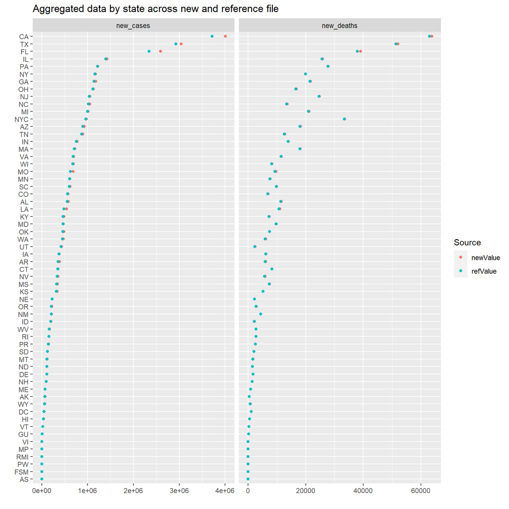

```
##
##
## ***Differences of at least 0 and at least 0.1%
##
##    state       name  newValue  refValue absDelta    pctDelta
## 1     IN tot_deaths   3407157   3378244    28913 0.008522120
## 2     SC tot_deaths   2291589   2305862    14273 0.006209093
## 3     CA tot_deaths  14183041  14129523    53518 0.003780512
## 4     NC tot_deaths   3073917   3062861    11056 0.003603194
## 5     MS tot_deaths   1998075   1991323     6752 0.003384972
## 6     KY tot_deaths   1634463   1630052     4411 0.002702392
## 7     RI tot_deaths    749883    751479     1596 0.002126070
## 8     NM tot_deaths   1001515    999916     1599 0.001597857
## 9     AL tot_deaths   2742024   2738028     3996 0.001458380
## 10    CA  tot_cases 865747767 837321729 28426038 0.033382123
```

[output cut: 56 more lines]

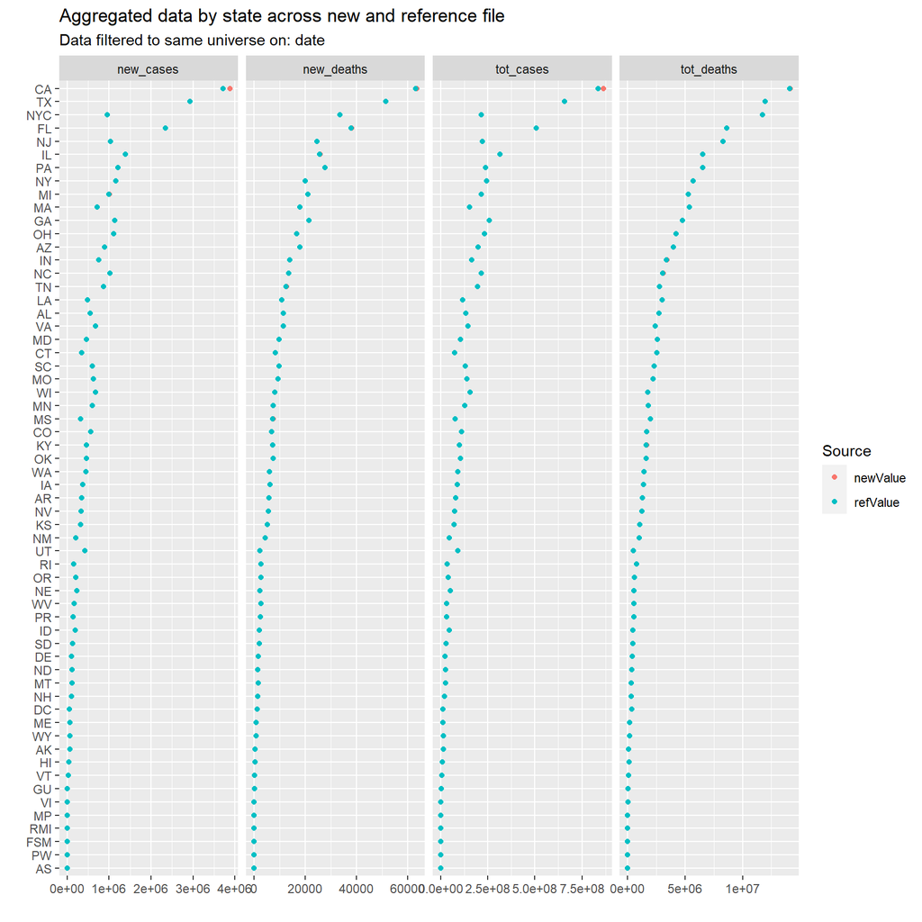

```
##
## *** File has been checked for uniqueness by: state date
```

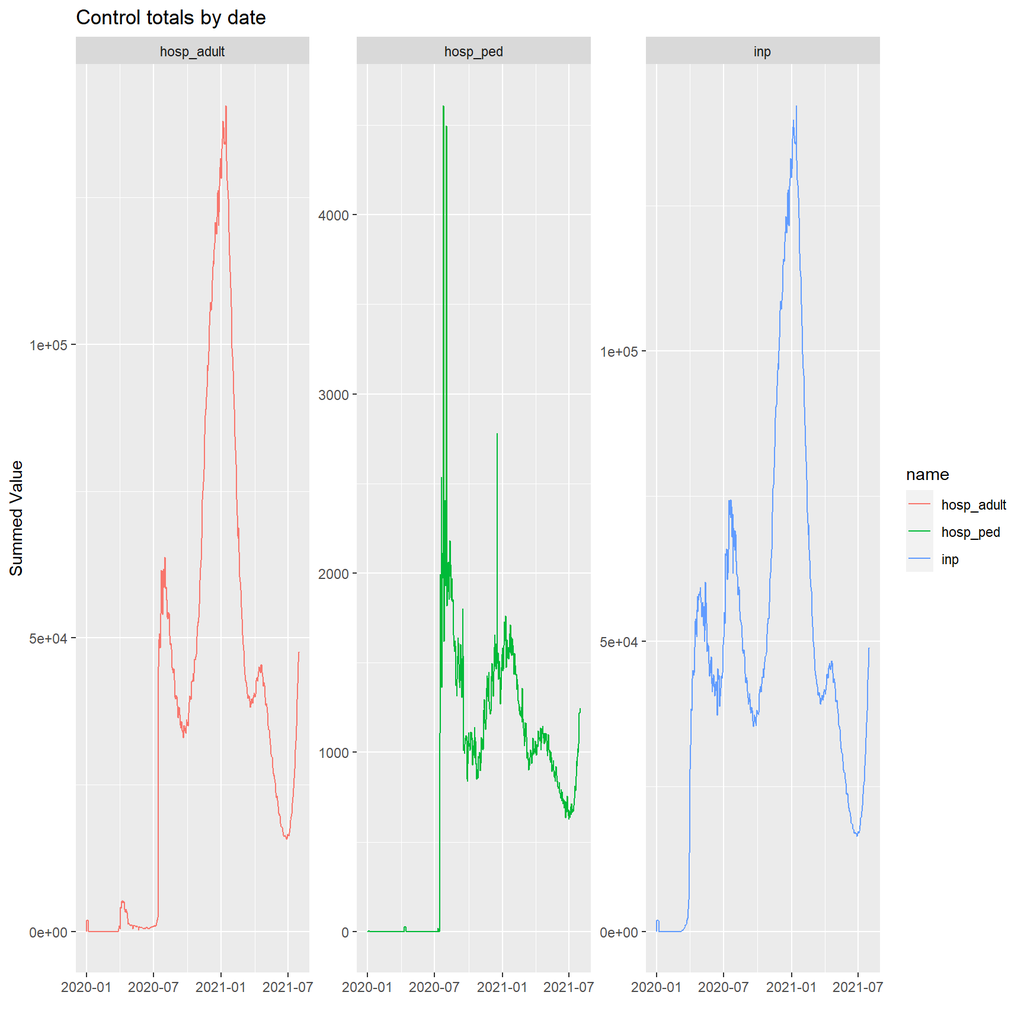

```
##
##
## Checking for similarity of: column names
## In reference but not in current:
## In current but not in reference:
##
## Checking for similarity of: date
## In reference but not in current: 0
## In current but not in reference: 28
##
## Checking for similarity of: state
## In reference but not in current:
## In current but not in reference:
```

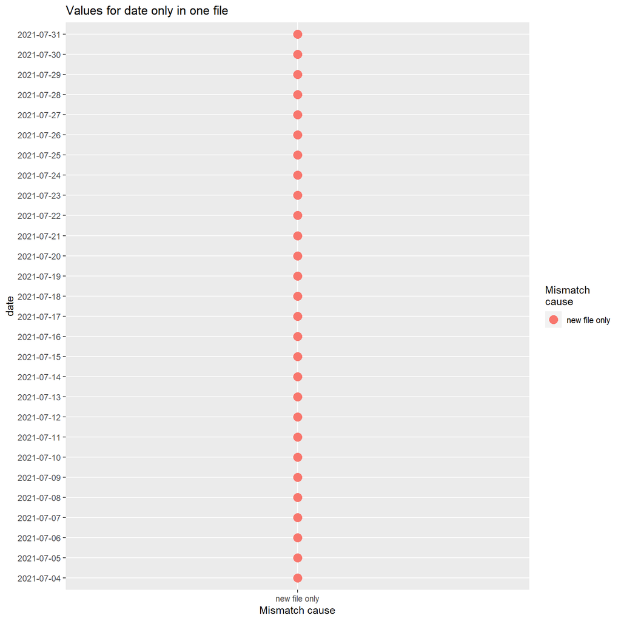

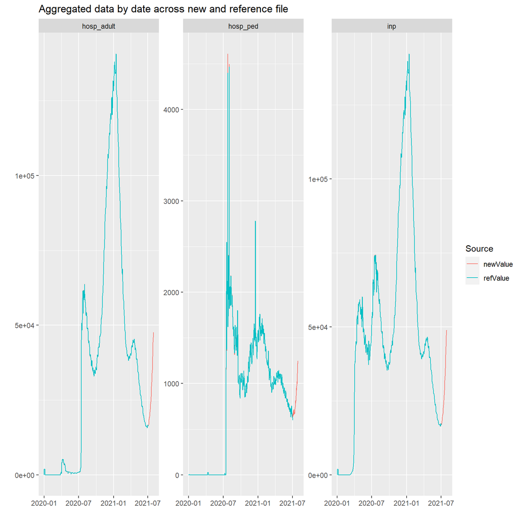

```
##
##
## ***Differences of at least 5 and at least 5%
##
##         date     name newValue refValue absDelta   pctDelta
## 1 2021-07-02 hosp_ped      662      597       65 0.10325655
## 2 2021-07-03 hosp_ped      638      597       41 0.06639676
```

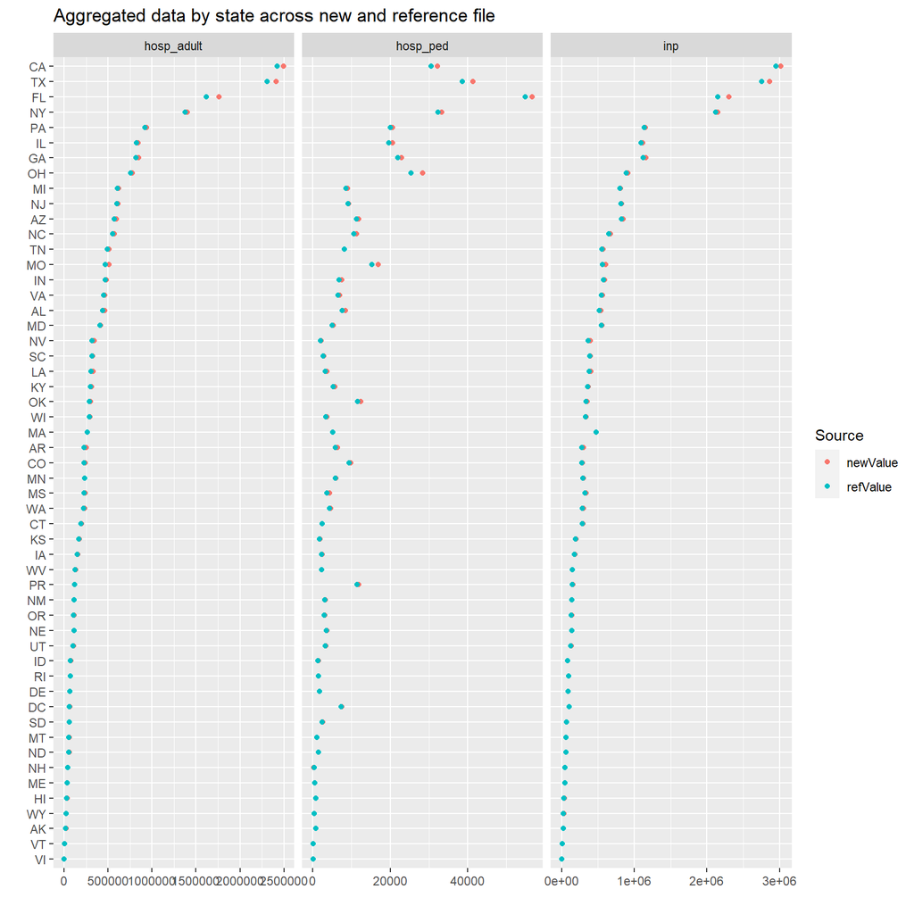

```
##
##
## ***Differences of at least 0 and at least 0.1%
##
##    state       name newValue refValue absDelta    pctDelta
## 1     AL        inp   523814   518483     5331 0.010229330
## 2     TN        inp   558512   559654     1142 0.002042631
## 3     NM        inp   137802   137991      189 0.001370593
## 4     NH   hosp_ped      271      361       90 0.284810127
## 5     ME   hosp_ped      452      509       57 0.118626431
## 6     KY   hosp_ped     5518     5308      210 0.038795492
## 7     MA   hosp_ped     5015     5201      186 0.036413469
## 8     AR   hosp_ped     5977     5840      137 0.023186934
## 9     TN   hosp_ped     7924     8102      178 0.022213902
## 10    DE   hosp_ped     1647     1683       36 0.021621622
```

[output cut: 142 more lines]

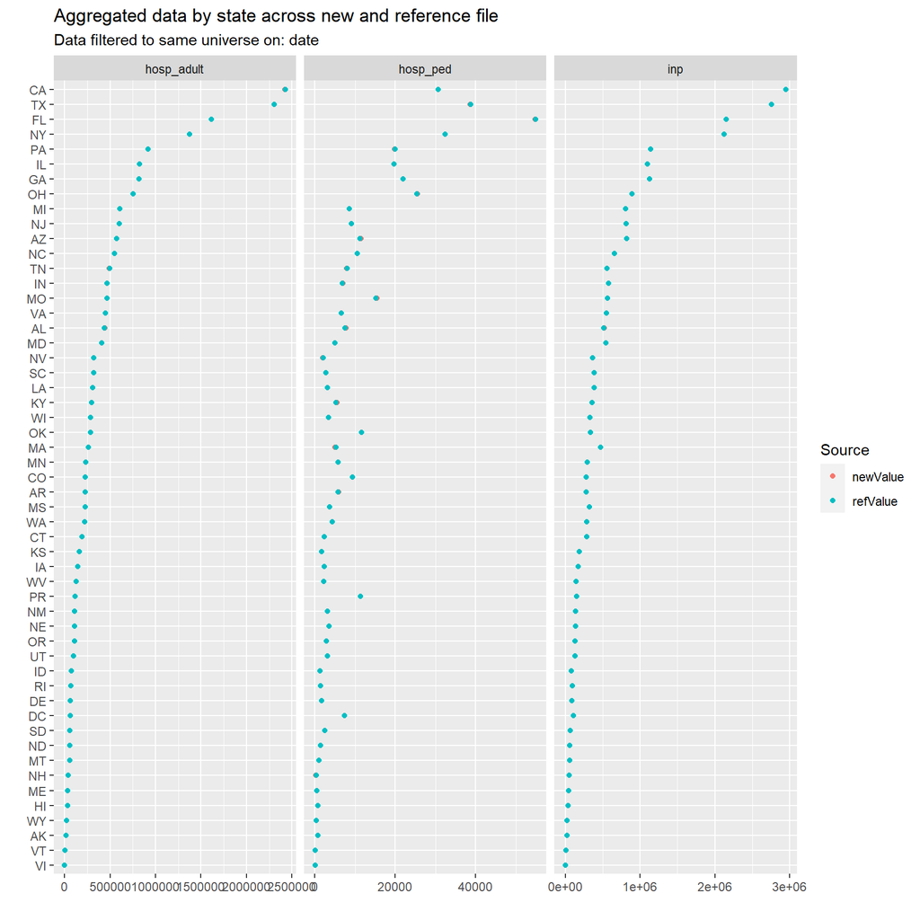

```
##
## *** File has been checked for uniqueness by: state date
```

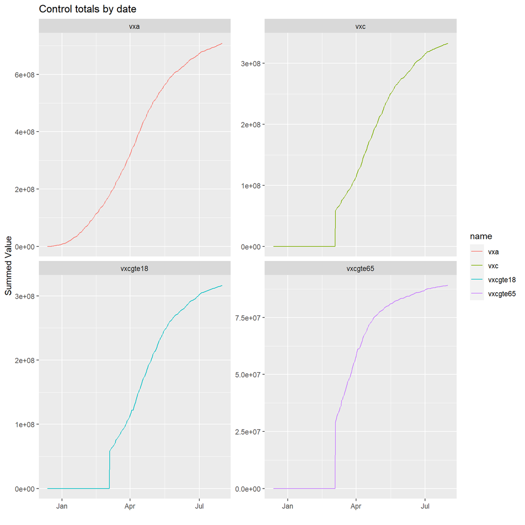

```
##
##
## Checking for similarity of: column names
## In reference but not in current:
## In current but not in reference:
##
## Checking for similarity of: date
## In reference but not in current: 0
## In current but not in reference: 4
##
## Checking for similarity of: state
## In reference but not in current:
## In current but not in reference:
```

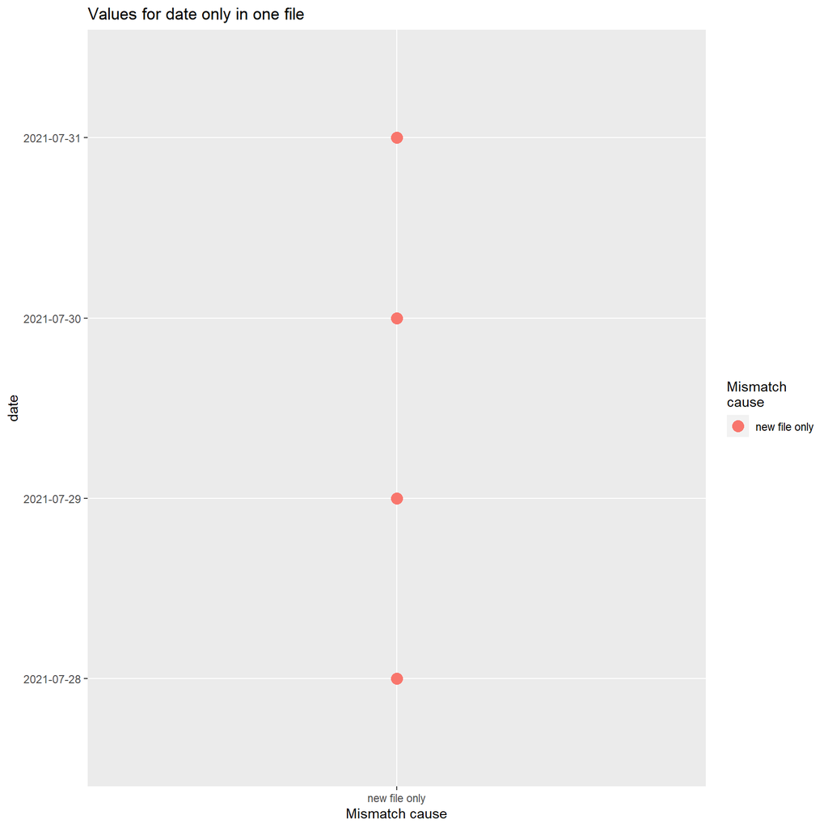

[6 more figures not shown]

```r
readList <- list("cdcDaily"="./RInputFiles/Coronavirus/CDC_dc_downloaded_210801.csv",
                 "cdcHosp"="./RInputFiles/Coronavirus/CDC_h_downloaded_210801.csv",
                 "vax"="./RInputFiles/Coronavirus/vaxData_downloaded_210801.csv"
                 )
compareList <- list("cdcDaily"=readFromRDS("cdc_daily_210708")$dfRaw$cdcDaily,
                    "cdcHosp"=readFromRDS("cdc_daily_210708")$dfRaw$cdcHosp,
                    "vax"=readFromRDS("cdc_daily_210728_vaxonly")$dfRaw$vax
                    )

cdc_daily_210801_test <- readRunCDCDaily(thruLabel="Jul 31, 2021",
                                         downloadTo=lapply(readList, FUN=function(x) if(file.exists(x)) NA else x),
                                         readFrom=readList,
                                         compareFile=compareList,
                                         writeLog=NULL,
                                         useClusters=readFromRDS("cdc_daily_210528")$useClusters,
                                         weightedMeanAggs=c("tcpm7", "tdpm7", "cpm7", "dpm7", "hpm7",
                                                            "vxcpm7", "vxcgte65pct"
                                                            ),
                                         skipAssessmentPlots=FALSE,
                                         brewPalette="Paired"
                                         )
```

```r
all.equal(names(cdc_daily_210801_test), names(readFromRDS("cdc_daily_210801")))
```

```
## [1] TRUE
```

```r
sapply(names(cdc_daily_210801_test), FUN=function(x)
    identical(cdc_daily_210801_test[[x]], readFromRDS("cdc_daily_210801")[[x]])
    )
```

```
##    stateData        dfRaw    dfProcess  dfPerCapita  useClusters plotDataList
##         TRUE         TRUE         TRUE         TRUE         TRUE        FALSE
```

```r
sapply(names(cdc_daily_210801_test$plotDataList), FUN=function(x)
    identical(cdc_daily_210801_test$plotDataList[[x]], readFromRDS("cdc_daily_210801")$plotDataList[[x]])
    )
```

```
##       dfFull        dfAgg plotClusters summaryPlots     detPlots
##         TRUE         TRUE         TRUE        FALSE        FALSE
```

As expected, all data elements are identical. Plot environments change with each creation, so the plot objects are not identical.

The latest data are downloaded and processed, with caching to avoid multiple file downloads:

```
##
## *** File has been checked for uniqueness by: state date
```

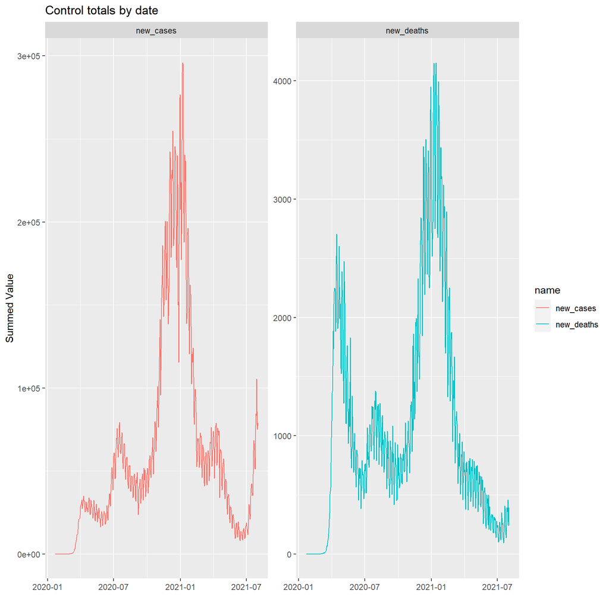

```
##
##
## Checking for similarity of: column names
## In reference but not in current:
## In current but not in reference:
##
## Checking for similarity of: date
## In reference but not in current: 0
## In current but not in reference: 28
##
## Checking for similarity of: state
## In reference but not in current:
## In current but not in reference:
```

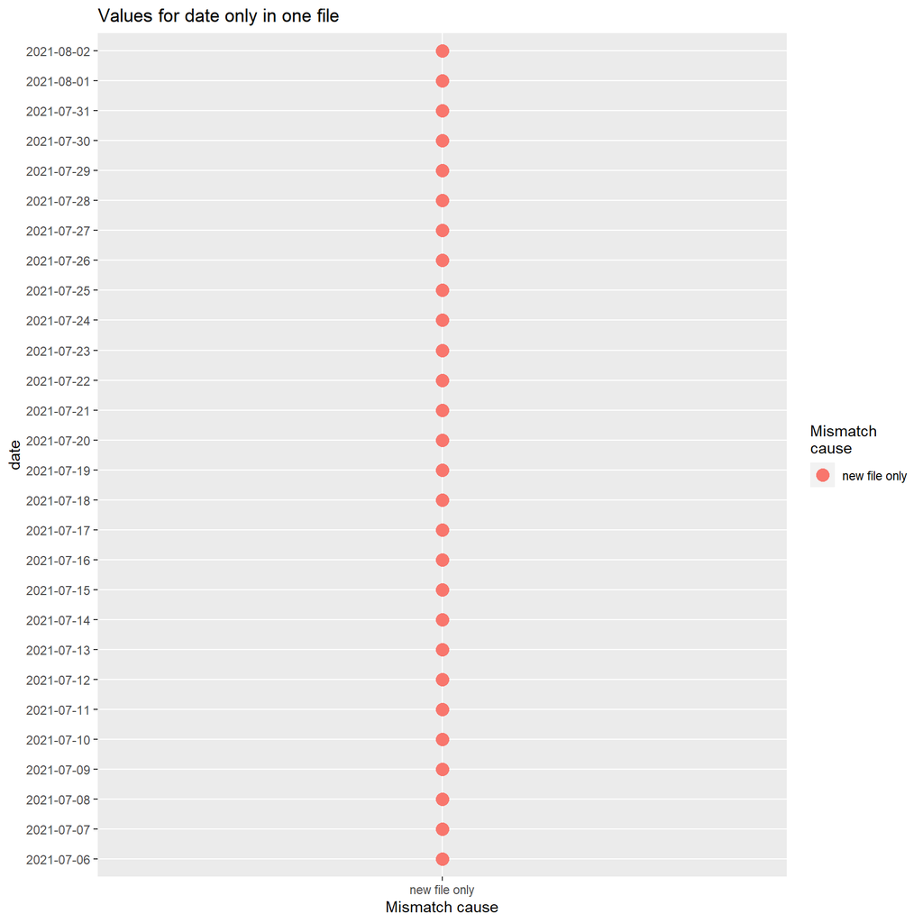

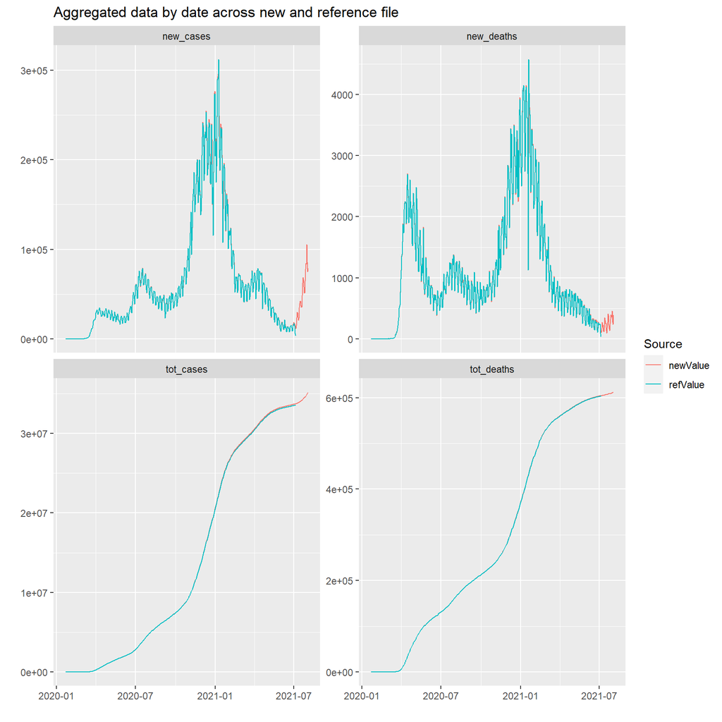

```
##
##
## ***Differences of at least 5 and at least 5%
##
##           date       name newValue refValue absDelta   pctDelta
## 1   2020-02-02 tot_deaths      143      152        9 0.06101695
## 2   2020-02-03 tot_deaths      143      152        9 0.06101695
## 3   2020-02-04 tot_deaths      143      152        9 0.06101695
## 4   2020-02-05 tot_deaths      143      152        9 0.06101695
## 5   2020-02-06 tot_deaths      143      152        9 0.06101695
## 6   2020-02-07 tot_deaths      143      152        9 0.06101695
## 7   2020-02-08 tot_deaths      144      153        9 0.06060606
## 8   2020-02-09 tot_deaths      144      153        9 0.06060606
## 9   2020-02-10 tot_deaths      144      153        9 0.06060606
## 10  2020-02-11 tot_deaths      144      153        9 0.06060606
```

[output cut: 110 more lines]

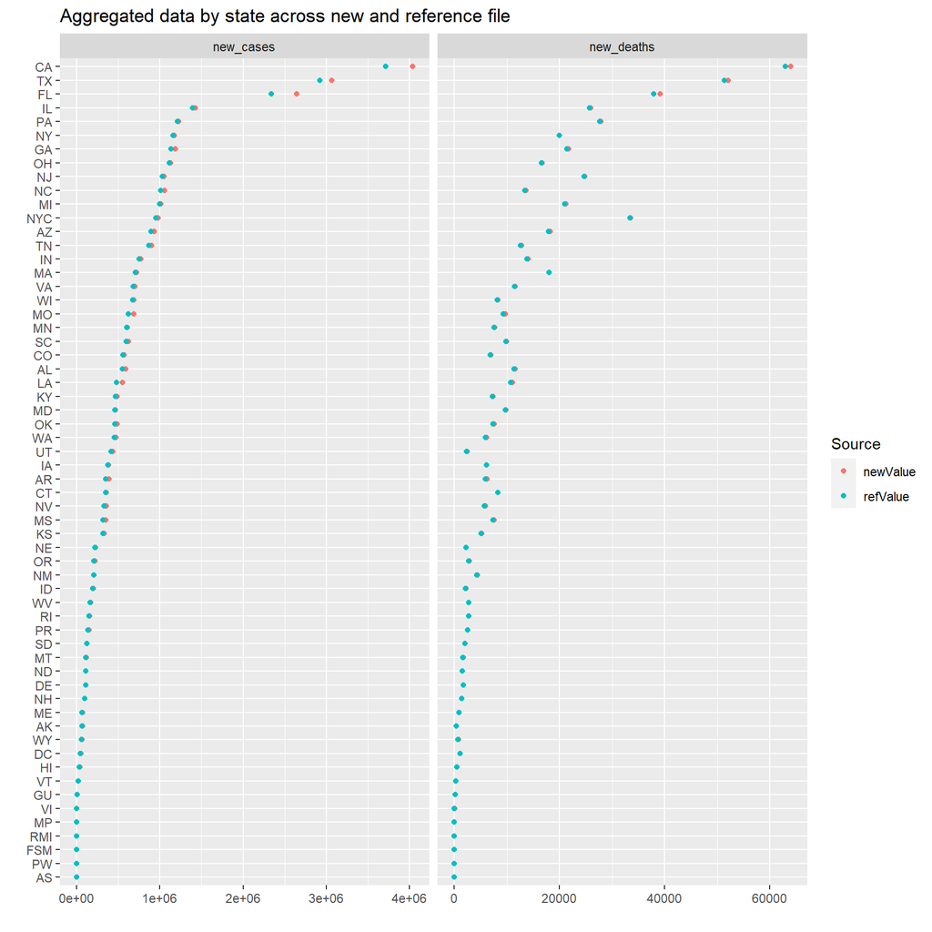

```
##
##
## ***Differences of at least 0 and at least 0.1%
##
##    state       name  newValue  refValue absDelta    pctDelta
## 1     IN tot_deaths   3407157   3378244    28913 0.008522120
## 2     SC tot_deaths   2291589   2305862    14273 0.006209093
## 3     CA tot_deaths  14183041  14129523    53518 0.003780512
## 4     NC tot_deaths   3073917   3062861    11056 0.003603194
## 5     MS tot_deaths   1998075   1991323     6752 0.003384972
## 6     KY tot_deaths   1634463   1630052     4411 0.002702392
## 7     AL tot_deaths   2743934   2738028     5906 0.002154703
## 8     RI tot_deaths    749883    751479     1596 0.002126070
## 9     NM tot_deaths   1001515    999916     1599 0.001597857
## 10    CA  tot_cases 865747767 837321729 28426038 0.033382123
```

[output cut: 54 more lines]

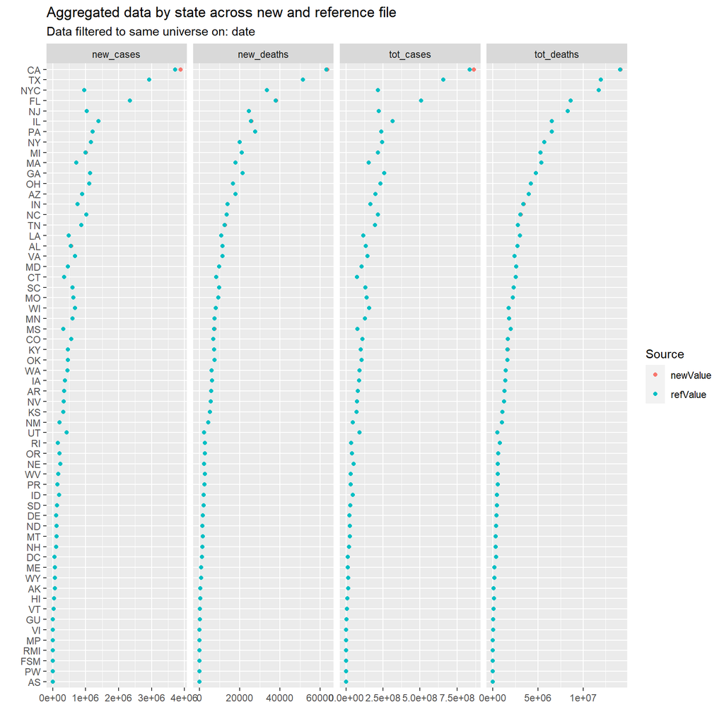

```
##
## *** File has been checked for uniqueness by: state date
```

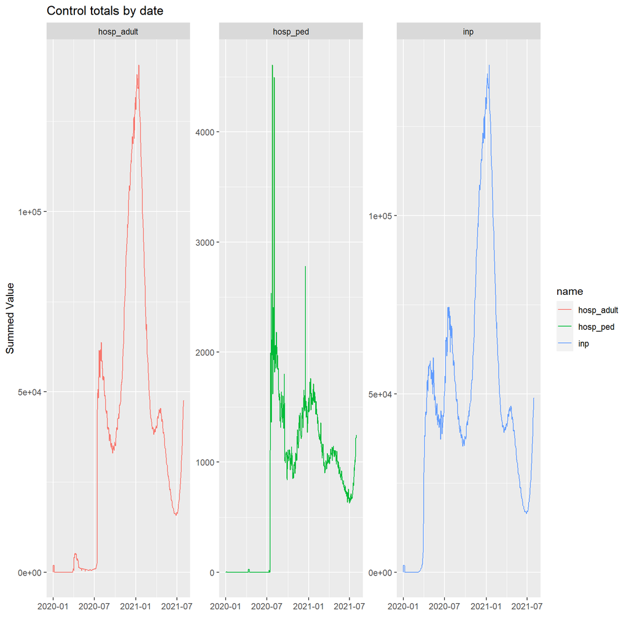

```
##
##
## Checking for similarity of: column names
## In reference but not in current:
## In current but not in reference:
##
## Checking for similarity of: date
## In reference but not in current: 0
## In current but not in reference: 28
##
## Checking for similarity of: state
## In reference but not in current:
## In current but not in reference:
```

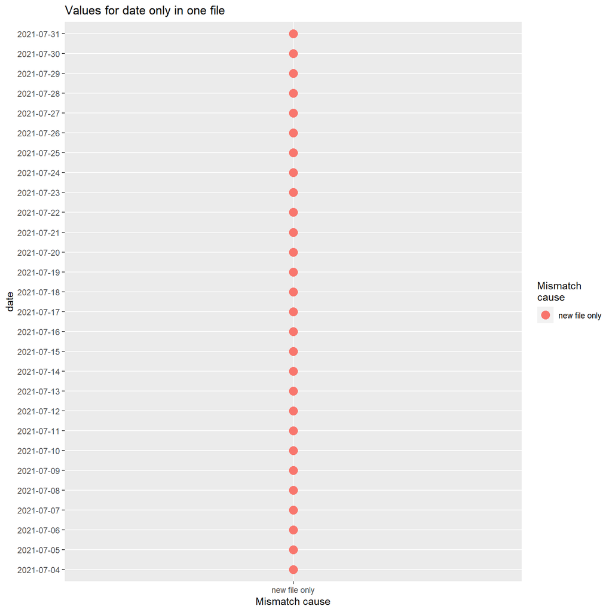

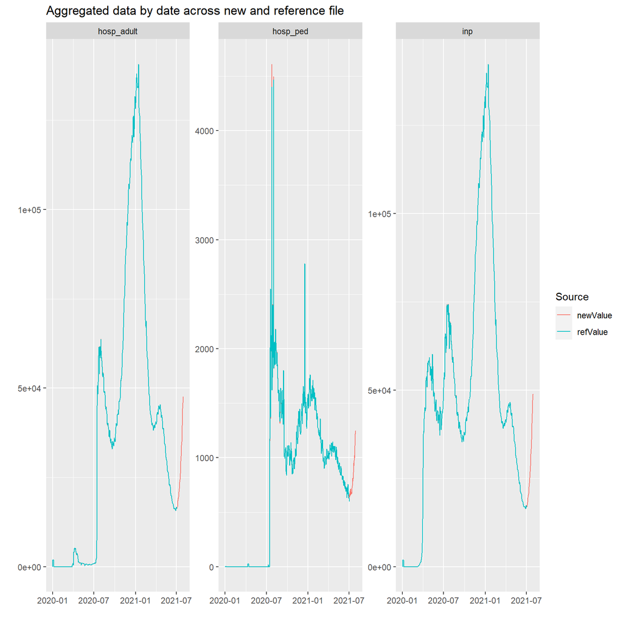

```
##
##
## ***Differences of at least 5 and at least 5%
##
##         date     name newValue refValue absDelta   pctDelta
## 1 2021-07-02 hosp_ped      662      597       65 0.10325655
## 2 2021-07-03 hosp_ped      638      597       41 0.06639676
```

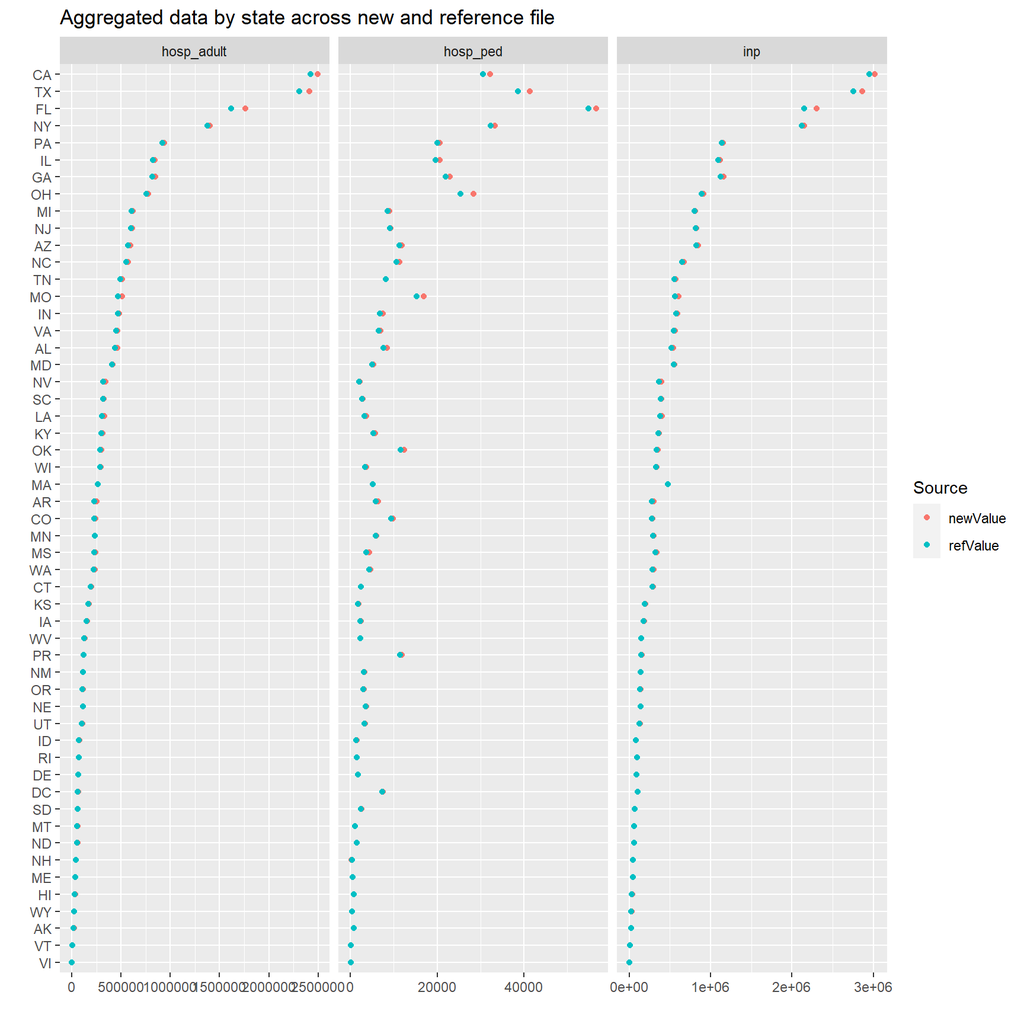

```
##
##
## ***Differences of at least 0 and at least 0.1%
##
##    state       name newValue refValue absDelta    pctDelta
## 1     AL        inp   523814   518483     5331 0.010229330
## 2     TN        inp   558512   559654     1142 0.002042631
## 3     NM        inp   137802   137991      189 0.001370593
## 4     NH   hosp_ped      271      361       90 0.284810127
## 5     ME   hosp_ped      452      509       57 0.118626431
## 6     KY   hosp_ped     5518     5308      210 0.038795492
## 7     MA   hosp_ped     5015     5201      186 0.036413469
## 8     AR   hosp_ped     5977     5840      137 0.023186934
## 9     TN   hosp_ped     7924     8102      178 0.022213902
## 10    DE   hosp_ped     1647     1683       36 0.021621622
```

[output cut: 140 more lines]

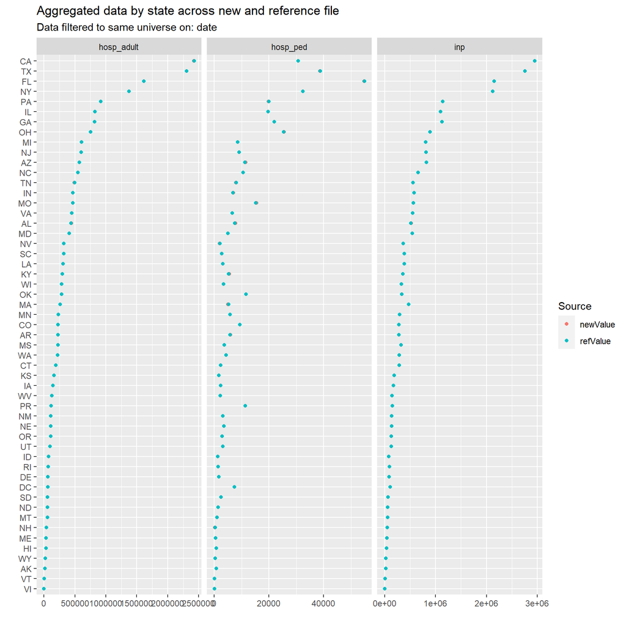

```
##
## *** File has been checked for uniqueness by: state date
```

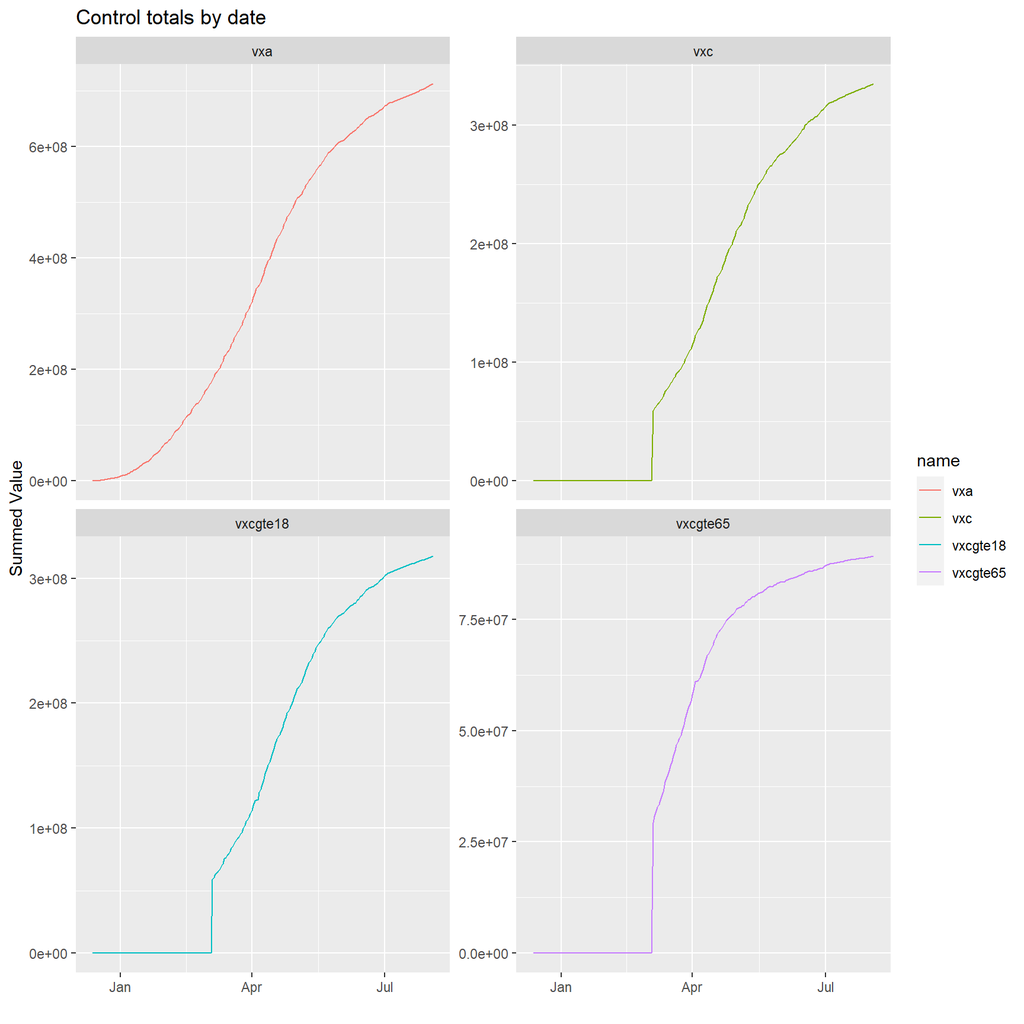

```
##
##
## Checking for similarity of: column names
## In reference but not in current:
## In current but not in reference:
##
## Checking for similarity of: date
## In reference but not in current: 0
## In current but not in reference: 7
##
## Checking for similarity of: state
## In reference but not in current:
## In current but not in reference:
```

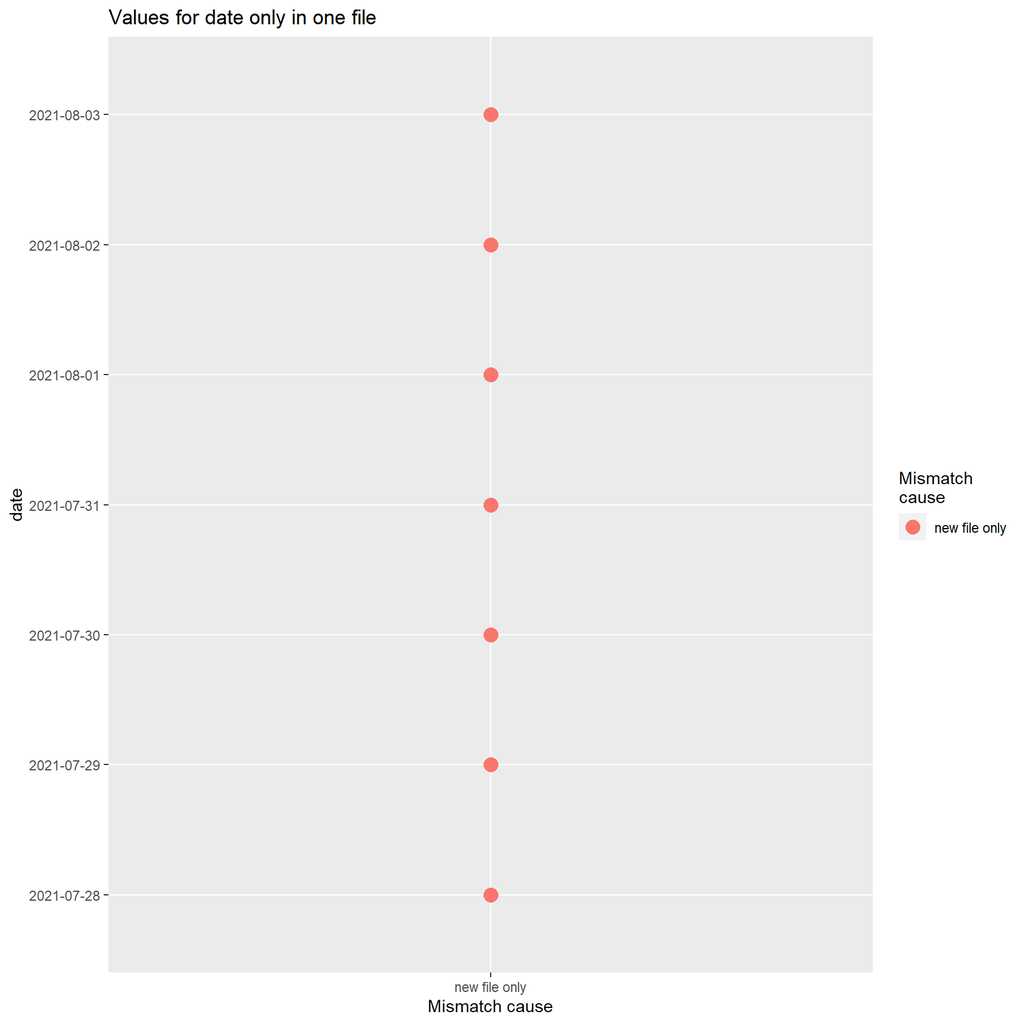

[6 more figures not shown]

```r
readList <- list("cdcDaily"="./RInputFiles/Coronavirus/CDC_dc_downloaded_210804.csv",
                 "cdcHosp"="./RInputFiles/Coronavirus/CDC_h_downloaded_210804.csv",
                 "vax"="./RInputFiles/Coronavirus/vaxData_downloaded_210804.csv"
                 )
compareList <- list("cdcDaily"=readFromRDS("cdc_daily_210708")$dfRaw$cdcDaily,
                    "cdcHosp"=readFromRDS("cdc_daily_210708")$dfRaw$cdcHosp,
                    "vax"=readFromRDS("cdc_daily_210728_vaxonly")$dfRaw$vax
                    )

cdc_daily_210804 <- readRunCDCDaily(thruLabel="Aug 3, 2021",
                                    downloadTo=lapply(readList, FUN=function(x) if(file.exists(x)) NA else x),
                                    readFrom=readList,
                                    compareFile=compareList,
                                    writeLog=NULL,
                                    useClusters=readFromRDS("cdc_daily_210528")$useClusters,
                                    weightedMeanAggs=c("tcpm7", "tdpm7", "cpm7", "dpm7", "hpm7",
                                                       "vxcpm7", "vxcgte65pct"
                                                       ),
                                    skipAssessmentPlots=FALSE,
                                    brewPalette="Paired"
                                    )
```

```r
saveToRDS(cdc_daily_210804)
```

The raw hospital data is explored for admissions with confirmed/suspected coronavirus:

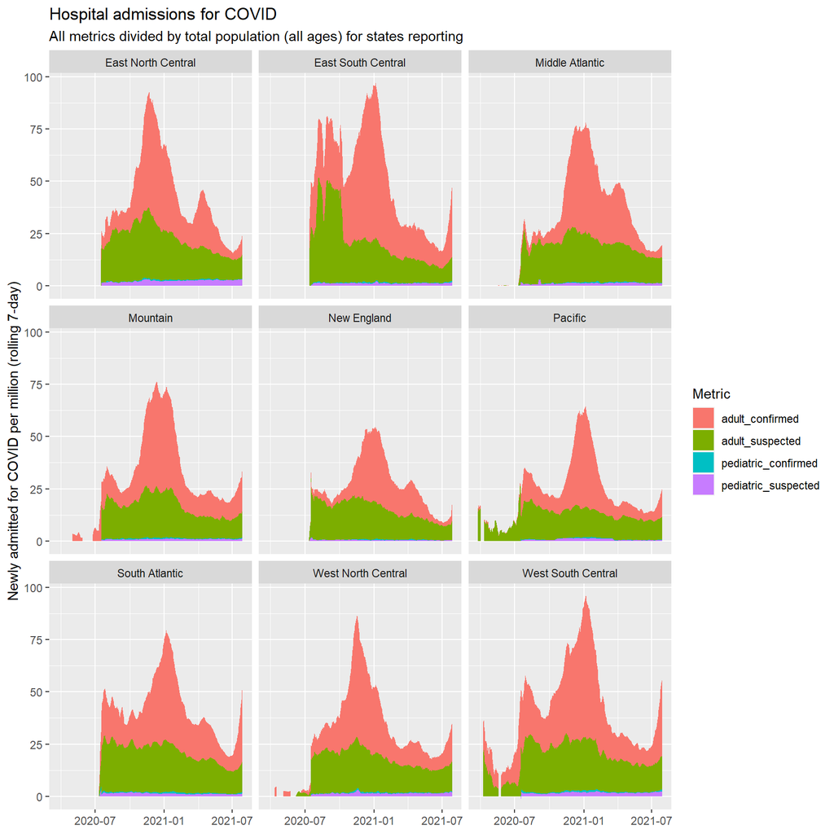

```r
cdcHospAdmit_210804 <- cdc_daily_210804$dfRaw$cdcHosp %>%
    select(state, date, ends_with("confirmed"), ends_with("suspected")) %>%
    filter(state %in% c(state.abb, "DC")) %>%
    arrange(date, state) %>%
    pivot_longer(-c(state, date)) %>%
    mutate(name=stringr::str_replace(name, pattern="previous_day_admission_", replacement=""),
           name=stringr::str_replace(name, pattern="_covid", replacement="")
           ) %>%
    left_join(getStateData(keepVars=c("state", "pop")), by="state") %>%
    mutate(vpm=1000000*value/pop) %>%
    group_by(state, name) %>%
    mutate(vpm7=zoo::rollmean(vpm, k=7, fill=NA)) %>%
    ungroup()

cdcHospAdmit_210804 %>%
    filter(!is.na(vpm7), state %in% state.abb) %>%
    mutate(div=as.character(state.division)[match(state, state.abb)]) %>%
    group_by(div, date, name) %>%
    summarize(wt_vpm7=sum(pop*vpm7)/sum(pop), tot_pop=sum(pop), .groups="drop") %>%
    ggplot(aes(x=date, y=wt_vpm7)) +
    geom_col(aes(fill=name), position="stack") +
    facet_wrap(~div) +
    scale_fill_discrete("Metric") +
    labs(x=NULL,
         y="Newly admitted for COVID per million (rolling 7-day)",
         title="Hospital admissions for COVID",
         subtitle="All metrics divided by total population (all ages) for states reporting"
         )
```

Hospital coverage data became robust about a year ago. The overwhelming majority of admissions are adult, split between confirmed and suspected cases. Next steps are to explore changes in admissions by age groups.